# Assignment1-Pathak-Cause Of Death 2014 2019

Rohan Pathak

2023-03-07

# Introduction

This dataset contains the number of deaths which occured in the United States of America due to broad selected causes. The data is divided into months for each year between 2014 to 2019.

Dataset Name- Monthly Counts of Deaths by Select Causes, 2014-2019

Dataset Source- U.S. Department of Health & Human Services

Dataset Link- https://catalog.data.gov/dataset/monthly-counts-of-deaths-by-select-causes-2014-2019-da9df

# Variable Names

```r
#Jurisdiction of Occurrence- Where deaths occured
#Year- Year of death
#Month- Month of death
#All Cause- Number of deaths by all causes
#Natural Cause- Number of deaths by the cause
#Septicemia- Number of deaths by the cause
#Malignant Neoplasms- Number of deaths by the cause
#Diabetes Mellitus- Number of deaths by the cause
#Alzheimer Disease- Number of deaths by the cause
#Influenza and Pneumonia- Number of deaths by the cause
#Chronic Lower Respiratory Diseases- Number of deaths by the cause
#Other Diseases of Respiratory System- Number of deaths by the cause
#Nephritis, Nephrotic Syndrome, and Nephrosis- Number of deaths by the cause
#Symptoms, Signs, and Abnormal Clinical and Laboratory Findings, Not Elsewhere Classified- Number of deaths by the cause
#Diseases of Heart- Number of deaths by the cause
#Cerebrovascular Diseases- Number of deaths by the cause
#Accidents (Unintentional Injuries)- Number of deaths by the cause
#Motor Vehicle Accidents- Number of deaths by the cause
#Intentional Self-Harm (Suicide)- Number of deaths by the cause
#Assault (Homicide)- Number of deaths by the cause
#Drug Overdose- Number of deaths by the cause
```

# Importing libraries

```r
#install.packages("ggplotify")
library(kableExtra)
library(tidyverse)
library(zoo)
library(ggplot2)
library(ggthemes)
library(stats)
#install.packages("seasonalityPlot")
library(forecast)
#install.packages('hrbrthemes')
library(hrbrthemes)
library(cowplot)
```

# Loading the messy data to R

```r
df=read_csv(file="Assignment1-Pathak-Cause Of Death 2014 2019.csv")
summary(df)
```

```
##  Jurisdiction of Occurrence      Year          Month         All Cause
##  Length:72                  Min.   :2014   Min.   : 1.00   Min.   :204687
##  Class :character           1st Qu.:2015   1st Qu.: 3.75   1st Qu.:219880
##  Mode  :character           Median :2016   Median : 6.50   Median :227895
##                             Mean   :2016   Mean   : 6.50   Mean   :230428
##                             3rd Qu.:2018   3rd Qu.: 9.25   3rd Qu.:237164
##                             Max.   :2019   Max.   :12.00   Max.   :286744
##  Natural Cause      Septicemia   Malignant Neoplasms Diabetes Mellitus
##  Min.   :187644   Min.   :2886   Min.   :45558       Min.   :5802
##  1st Qu.:199788   1st Qu.:3120   1st Qu.:48776       1st Qu.:6454
##  Median :208178   Median :3248   Median :49820       Median :6714
##  Mean   :211008   Mean   :3339   Mean   :49773       Mean   :6837
##  3rd Qu.:216745   3rd Qu.:3528   3rd Qu.:50881       3rd Qu.:7155
##  Max.   :265418   Max.   :4502   Max.   :52876       Max.   :8674
##  Alzheimer Disease Influenza and Pneumonia Chronic Lower Respiratory Diseases
##  Min.   : 6755     Min.   : 2882           Min.   :10426
##  1st Qu.: 8934     1st Qu.: 3407           1st Qu.:11680
##  Median : 9419     Median : 3876           Median :12308
##  Mean   : 9516     Mean   : 4561           Mean   :12964
##  3rd Qu.:10130     3rd Qu.: 5195           3rd Qu.:14034
##  Max.   :13410     Max.   :12164           Max.   :18271
##  Other Diseases of Respiratory System
##  Min.   :2690
##  1st Qu.:3129
##  Median :3330
##  Mean   :3379
##  3rd Qu.:3648
##  Max.   :4603
##  Nephritis, Nephrotic Syndrome, and Nephrosis
##  Min.   :3631
##  1st Qu.:3926
##  Median :4110
##  Mean   :4191
##  3rd Qu.:4373
##  Max.   :5346
##  Symptoms, Signs, and Abnormal Clinical and Laboratory Findings, Not Elsewhere Classified
##  Min.   :2449
##  1st Qu.:2551
##  Median :2634
##  Mean   :2713
```

[output cut: 8 more lines]

```
##  Max.   :67024     Max.   :14653            Max.   :15292
##  Motor Vehicle Accidents Intentional Self-Harm (Suicide) Assault (Homicide)
##  Min.   :2248            Min.   :3091                    Min.   :1050
##  1st Qu.:3029            1st Qu.:3597                    1st Qu.:1435
##  Median :3262            Median :3836                    Median :1564
##  Mean   :3225            Mean   :3820                    Mean   :1535
##  3rd Qu.:3517            3rd Qu.:4042                    3rd Qu.:1658
##  Max.   :3834            Max.   :4378                    Max.   :1804
##  Drug Overdose
##  Min.   :3733
##  1st Qu.:4435
##  Median :5478
##  Mean   :5157
##  3rd Qu.:5820
##  Max.   :6299
```

The data has multiple columns for different causes of death, which is the same kind of observation, thus they should instead be placed in a single column according to the rules of tidy data.

```r
df[1:10, 1:5] %>%
  kbl() %>%
  kable_paper("hover", full_width = F, fixed_thead = T)
```

| Jurisdiction of Occurrence | Year | Month | All Cause | Natural Cause |
| --- | --- | --- | --- | --- |
| United States | 2014 | 1 | 243298 | 226621 |
| United States | 2015 | 1 | 265355 | 247269 |
| United States | 2016 | 1 | 245823 | 227341 |
| United States | 2017 | 1 | 262832 | 241918 |
| United States | 2018 | 1 | 286744 | 265418 |
| United States | 2019 | 1 | 257649 | 237219 |
| United States | 2014 | 2 | 211980 | 197001 |
| United States | 2015 | 2 | 227047 | 211028 |
| United States | 2016 | 2 | 230021 | 212140 |
| United States | 2017 | 2 | 233819 | 215160 |

# Data Tidying-

Tidying the data by pivot longer on the different columns capturing cause of death into a single column called “Cause of Death” with the values moved to a new column “Cases”

```r
tid_df<-df %>%
  pivot_longer(c("All Cause", "Natural Cause", "Septicemia",
                "Malignant Neoplasms", "Diabetes Mellitus",
                "Alzheimer Disease", "Influenza and Pneumonia",
                "Chronic Lower Respiratory Diseases",
                "Other Diseases of Respiratory System",
                "Nephritis, Nephrotic Syndrome, and Nephrosis",
                "Symptoms, Signs, and Abnormal Clinical and Laboratory Findings, Not Elsewhere Classified", "Diseases of Heart",
                "Cerebrovascular Diseases", "Accidents (Unintentional Injuries)",
                "Motor Vehicle Accidents", "Intentional Self-Harm (Suicide)",
                "Assault (Homicide)", "Drug Overdose"),
               names_to = "Cause_of_Death", values_to = "Cases")
```

Now the dataset is following the three main rules of tidy dataset- Each variable must have its own column. - Fixed by pivot_longer Each observation must have its own row. - Fixed by pivot_longer Each value must have its own cell.

```r
tid_df[1:10, 1:5] %>%
  kbl() %>%
  kable_paper("hover", full_width = F, fixed_thead = T)
```

| Jurisdiction of Occurrence | Year | Month | Cause_of_Death | Cases |
| --- | --- | --- | --- | --- |
| United States | 2014 | 1 | All Cause | 243298 |
| United States | 2014 | 1 | Natural Cause | 226621 |
| United States | 2014 | 1 | Septicemia | 3944 |
| United States | 2014 | 1 | Malignant Neoplasms | 51101 |
| United States | 2014 | 1 | Diabetes Mellitus | 7344 |
| United States | 2014 | 1 | Alzheimer Disease | 8305 |
| United States | 2014 | 1 | Influenza and Pneumonia | 7929 |
| United States | 2014 | 1 | Chronic Lower Respiratory Diseases | 15078 |
| United States | 2014 | 1 | Other Diseases of Respiratory System | 3466 |
| United States | 2014 | 1 | Nephritis, Nephrotic Syndrome, and Nephrosis | 4600 |

# Data Wrangling-

Now doing Exploratory Data Analysis, we see there are no missing values, the column Jurisdiction of Occurrence” has only one value, so it can be dropped.

```r
glimpse(tid_df)
```

```
## Rows: 1,296
## Columns: 5
## $ `Jurisdiction of Occurrence` <chr> "United States", "United States", "United…
## $ Year                         <dbl> 2014, 2014, 2014, 2014, 2014, 2014, 2014,…
## $ Month                        <dbl> 1, 1, 1, 1, 1, 1, 1, 1, 1, 1, 1, 1, 1, 1,…
## $ Cause_of_Death               <chr> "All Cause", "Natural Cause", "Septicemia…
## $ Cases                        <dbl> 243298, 226621, 3944, 51101, 7344, 8305, …
```

```r
tid_df<-tid_df[,-1]
tid_df[1:10,] %>%
  kbl() %>%
  kable_paper("hover", full_width = F, fixed_thead = T)
```

| Year | Month | Cause_of_Death | Cases |
| --- | --- | --- | --- |
| 2014 | 1 | All Cause | 243298 |
| 2014 | 1 | Natural Cause | 226621 |
| 2014 | 1 | Septicemia | 3944 |
| 2014 | 1 | Malignant Neoplasms | 51101 |
| 2014 | 1 | Diabetes Mellitus | 7344 |
| 2014 | 1 | Alzheimer Disease | 8305 |
| 2014 | 1 | Influenza and Pneumonia | 7929 |
| 2014 | 1 | Chronic Lower Respiratory Diseases | 15078 |
| 2014 | 1 | Other Diseases of Respiratory System | 3466 |
| 2014 | 1 | Nephritis, Nephrotic Syndrome, and Nephrosis | 4600 |

We can also combine the Year and Month columns into a single date using unite as described below.

```r
tid_df2<-tid_df
tid_df2 %>%
  unite(Year, Month, Year, sep=" ")
```

```
## # A tibble: 1,296 × 3
##    Year   Cause_of_Death                                Cases
##    <chr>  <chr>                                         <dbl>
##  1 1 2014 All Cause                                    243298
##  2 1 2014 Natural Cause                                226621
##  3 1 2014 Septicemia                                     3944
##  4 1 2014 Malignant Neoplasms                           51101
##  5 1 2014 Diabetes Mellitus                              7344
##  6 1 2014 Alzheimer Disease                              8305
##  7 1 2014 Influenza and Pneumonia                        7929
##  8 1 2014 Chronic Lower Respiratory Diseases            15078
##  9 1 2014 Other Diseases of Respiratory System           3466
## 10 1 2014 Nephritis, Nephrotic Syndrome, and Nephrosis   4600
## # … with 1,286 more rows
```

Instead we will use zoo yearmon function to get a date object. Removing the Month and Year column, then moving the newly created Date column to the beginning.

```r
tid_df$Date <- as.yearmon(paste(tid_df$Year, tid_df$Month), "%Y %m")
tidy_df <- tid_df %>%
  select(Date, everything())
tidy_df<-tidy_df[,-2]
tidy_df<-tidy_df[,-2]
class(tidy_df$Date)
```

```
## [1] "yearmon"
```

```r
tidy_df[1:10,] %>%
  kbl() %>%
  kable_paper("hover", full_width = F, fixed_thead = T)
```

| Date | Cause_of_Death | Cases |
| --- | --- | --- |
| Jan 2014 | All Cause | 243298 |
| Jan 2014 | Natural Cause | 226621 |
| Jan 2014 | Septicemia | 3944 |
| Jan 2014 | Malignant Neoplasms | 51101 |
| Jan 2014 | Diabetes Mellitus | 7344 |
| Jan 2014 | Alzheimer Disease | 8305 |
| Jan 2014 | Influenza and Pneumonia | 7929 |
| Jan 2014 | Chronic Lower Respiratory Diseases | 15078 |
| Jan 2014 | Other Diseases of Respiratory System | 3466 |
| Jan 2014 | Nephritis, Nephrotic Syndrome, and Nephrosis | 4600 |

Creating a dataframe to add day and arrange date to %Y-%m-%d format and sort by date

```r
df3<-tidy_df
df3$Date <- as.Date(df3$Date)
df3 %>% arrange(mdy(df3$Date))
```

```
## # A tibble: 1,296 × 3
##    Date       Cause_of_Death                                Cases
##    <date>     <chr>                                         <dbl>
##  1 2014-01-01 All Cause                                    243298
##  2 2014-01-01 Natural Cause                                226621
##  3 2014-01-01 Septicemia                                     3944
##  4 2014-01-01 Malignant Neoplasms                           51101
##  5 2014-01-01 Diabetes Mellitus                              7344
##  6 2014-01-01 Alzheimer Disease                              8305
##  7 2014-01-01 Influenza and Pneumonia                        7929
##  8 2014-01-01 Chronic Lower Respiratory Diseases            15078
##  9 2014-01-01 Other Diseases of Respiratory System           3466
## 10 2014-01-01 Nephritis, Nephrotic Syndrome, and Nephrosis   4600
## # … with 1,286 more rows
```

```r
df3<-df3[order(as.Date(df3$Date, format="%Y-%m-%d")),]
df3[1:10,] %>%
  kbl() %>%
  kable_paper("hover", full_width = F, fixed_thead = T)
```

| Date | Cause_of_Death | Cases |
| --- | --- | --- |
| 2014-01-01 | All Cause | 243298 |
| 2014-01-01 | Natural Cause | 226621 |
| 2014-01-01 | Septicemia | 3944 |
| 2014-01-01 | Malignant Neoplasms | 51101 |
| 2014-01-01 | Diabetes Mellitus | 7344 |
| 2014-01-01 | Alzheimer Disease | 8305 |
| 2014-01-01 | Influenza and Pneumonia | 7929 |
| 2014-01-01 | Chronic Lower Respiratory Diseases | 15078 |
| 2014-01-01 | Other Diseases of Respiratory System | 3466 |
| 2014-01-01 | Nephritis, Nephrotic Syndrome, and Nephrosis | 4600 |

# Data Visualization with inferences-

Creating plot with just the data for “All Cause” to see the outlier months with most deaths

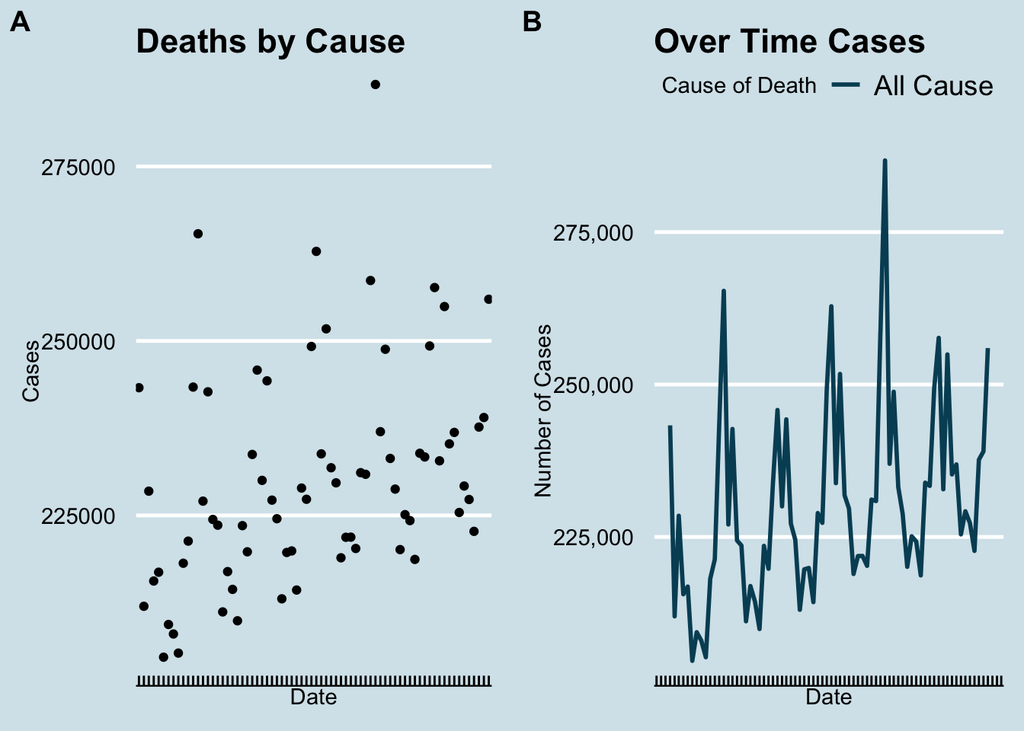

```r
df2<-df3[df3$Cause_of_Death == 'All Cause', ]
df2$Date <- as.Date(df2$Date)
pl1<-ggplot(data = df2,
       mapping = aes(x = factor(Date),
                     y = Cases)) +
  geom_point() +
  geom_smooth() +
  theme_economist() +
  scale_colour_economist()+
  labs(title = "Deaths by Cause",
       x = "Date",
       y = "Cases") +
  theme(axis.text.x=element_blank(),
      )

pl2<-ggplot(df2, aes(x = Date, y = Cases, color = Cause_of_Death,
                group = Cause_of_Death)) +
  geom_line(size = 1) +
  scale_x_date(date_labels = "%b-%y", date_breaks = "1 month") +
  scale_y_continuous(labels = scales::comma) +
  labs(x = "Date", y = "Number of Cases", color = "Cause of Death") +
  ggtitle("Over Time Cases") +
  theme(plot.title = element_text(size = 20, hjust = 0.5),
        axis.title = element_text(size = 16),
        axis.text = element_text(size = 14),
        legend.title = element_text(size = 14),
        legend.text = element_text(size = 12),
        legend.position = "bottom"
        ) +
  theme_economist() +
  scale_colour_economist()+
  theme(axis.text.x=element_blank(),)

plot_grid(pl1, pl2, labels = "AUTO")
```

As we can see from the above plots, the overall trend of the total number of deaths is increasing over the years, with certain months being outliers. Like in the above plots, the months of January and December over the years are the outliers. This proves the conventional wisdom that winter months have the most deaths

Since the majority of deaths are due to natural causes, we drop the rows for them to see the significant reasons for other causes of deaths

```r
df_drop<-df3[is.element(df3$Cause_of_Death, c("Septicemia",
                                              "Malignant Neoplasms", "Diabetes Mellitus",
                                              "Alzheimer Disease", "Influenza and Pneumonia",
                                              "Chronic Lower Respiratory Diseases",
                                              "Other Diseases of Respiratory System",
                                              "Nephritis, Nephrotic Syndrome, and Nephrosis",
                                              "Symptoms, Signs, and Abnormal Clinical and Laboratory Findings, Not Elsewhere Classified",
                                              "Diseases of Heart",
                                              "Cerebrovascular Diseases", "Accidents (Unintentional Injuries)",
                                              "Motor Vehicle Accidents", "Intentional Self-Harm (Suicide)",
                                              "Assault (Homicide)", "Drug Overdose")),]

df_drop[1:10,] %>%
  kbl() %>%
  kable_paper("hover", full_width = F, fixed_thead = T)
```

| Date | Cause_of_Death | Cases |
| --- | --- | --- |
| 2014-01-01 | Septicemia | 3944 |
| 2014-01-01 | Malignant Neoplasms | 51101 |
| 2014-01-01 | Diabetes Mellitus | 7344 |
| 2014-01-01 | Alzheimer Disease | 8305 |
| 2014-01-01 | Influenza and Pneumonia | 7929 |
| 2014-01-01 | Chronic Lower Respiratory Diseases | 15078 |
| 2014-01-01 | Other Diseases of Respiratory System | 3466 |
| 2014-01-01 | Nephritis, Nephrotic Syndrome, and Nephrosis | 4600 |
| 2014-01-01 | Symptoms, Signs, and Abnormal Clinical and Laboratory Findings, Not Elsewhere Classified | 2815 |
| 2014-01-01 | Diseases of Heart | 58229 |

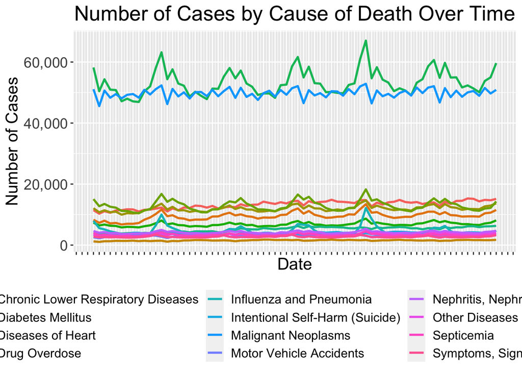

```r
ggplot(df_drop, aes(x = Date, y = Cases, color = Cause_of_Death, group = Cause_of_Death)) +
  geom_line(size = 1) +
  scale_x_date(date_labels = "%b-%y", date_breaks = "1 month") +
  scale_y_continuous(labels = scales::comma) +
  labs(x = "Date", y = "Number of Cases", color = "Cause of Death") +
  ggtitle("Number of Cases by Cause of Death Over Time") +
  theme(plot.title = element_text(size = 20, hjust = 0.5),
        axis.title = element_text(size = 16),
        axis.text = element_text(size = 14),
        legend.title = element_text(size = 14),
        legend.text = element_text(size = 12),
        legend.position = "bottom") +
  theme(axis.text.x=element_blank(),)
```

The initial observation about winter months holds true, thus the data is seasonal in nature. It is interesting to see that the trend is valid for most of the causes of deaths, with the sharpest jumps in diseases of heart. We also see that deaths due to Diseases of Heart and Malignant Neoplasm far outweighs other reasons.

```r
df_drop3<-df_drop %>%
  mutate(day = format(Date, "%d"),month = format(Date, "%m"),
         year = format(Date, "%Y")) %>%
  group_by(year,Cause_of_Death) %>%
  summarise(total = sum(Cases))

df_drop3[1:10,] %>%
  kbl() %>%
  kable_paper("hover", full_width = F, fixed_thead = T)
```

| year | Cause_of_Death | total |
| --- | --- | --- |
| 2014 | Accidents (Unintentional Injuries) | 135928 |
| 2014 | Alzheimer Disease | 93541 |
| 2014 | Assault (Homicide) | 15872 |
| 2014 | Cerebrovascular Diseases | 133103 |
| 2014 | Chronic Lower Respiratory Diseases | 147101 |
| 2014 | Diabetes Mellitus | 76488 |
| 2014 | Diseases of Heart | 614348 |
| 2014 | Drug Overdose | 47055 |
| 2014 | Influenza and Pneumonia | 55227 |
| 2014 | Intentional Self-Harm (Suicide) | 42826 |

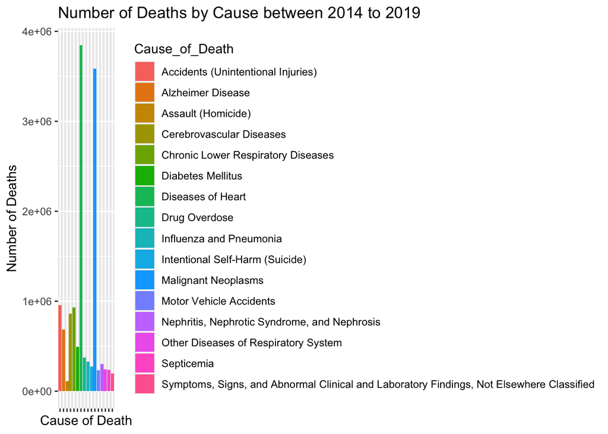

```r
ggplot(df_drop3, aes(x=Cause_of_Death, y=total, fill=Cause_of_Death)) +
  geom_bar(stat="identity") +
  xlab("Cause of Death") +
  ylab("Number of Deaths") +
  ggtitle("Number of Deaths by Cause between 2014 to 2019")  +
  theme(axis.text.x=element_blank(),)
```

From the above graph we can see that after Diseases of Heart and Malignant Neoplasms, the top three causes are Accidents, Cerebrovascular, and Respiratory diseases

Now to find the overall changes in the top causes over the 5 year period, we filter the dataset to only include data for 2014 and 2019

```r
deaths_2014 <- df_drop3[df_drop3$year == 2014,]
deaths_2019 <- df_drop3[df_drop3$year == 2019,]
```

Sort the data by total number of deaths in descending order

```r
deaths_2014 <- deaths_2014[order(-deaths_2014$total),]
deaths_2019 <- deaths_2019[order(-deaths_2019$total),]
```

Create a bar plot of the top 10 causes of death in 2014 and 2019

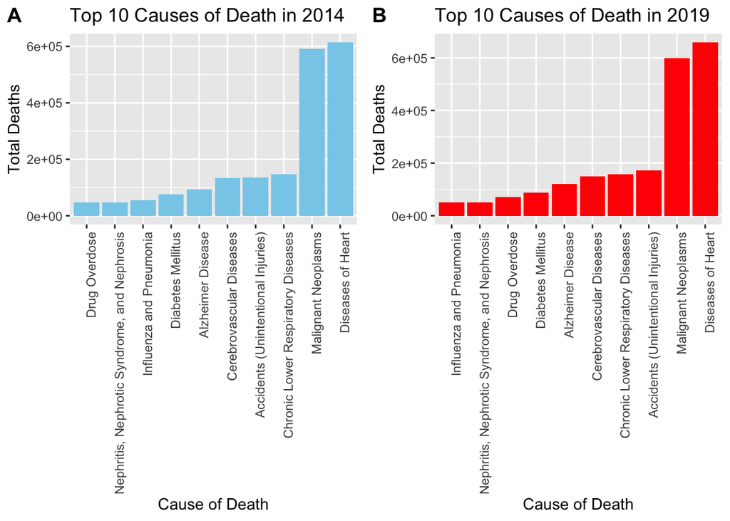

```r
gplot1<-ggplot(data = head(deaths_2014, 10), aes(x = reorder(Cause_of_Death, total), y = total)) +
  geom_bar(stat = "identity", fill = "skyblue") +
  ggtitle("Top 10 Causes of Death in 2014") +
  xlab("Cause of Death") +
  ylab("Total Deaths") +
  theme(axis.text.x = element_text(angle = 90, hjust = 1))
gplot2<-ggplot(data = head(deaths_2019, 10), aes(x = reorder(Cause_of_Death, total), y = total)) +
  geom_bar(stat = "identity", fill = "red") +
  ggtitle("Top 10 Causes of Death in 2019") +
  xlab("Cause of Death") +
  ylab("Total Deaths") +
  theme(axis.text.x = element_text(angle = 90, hjust = 1))

plot_grid(gplot1, gplot2, labels = "AUTO")
```

Accidents seem to have overtaken the number of deaths due to Respiratory diseases in 2019. Another observation, the number of deaths due to Heart disease has markedly increased compared to due to Neoplasms which seems to be close to the 2014 number.

Now to see overall trends in changes for Cause of death. We group data to year

```r
deaths_grouped <- aggregate(total ~ Cause_of_Death + year, data = df_drop3, sum)

deaths_grouped[1:10,] %>%
  kbl() %>%
  kable_paper("hover", full_width = F, fixed_thead=T)
```

| Cause_of_Death | year | total |
| --- | --- | --- |
| Accidents (Unintentional Injuries) | 2014 | 135928 |
| Alzheimer Disease | 2014 | 93541 |
| Assault (Homicide) | 2014 | 15872 |
| Cerebrovascular Diseases | 2014 | 133103 |
| Chronic Lower Respiratory Diseases | 2014 | 147101 |
| Diabetes Mellitus | 2014 | 76488 |
| Diseases of Heart | 2014 | 614348 |
| Drug Overdose | 2014 | 47055 |
| Influenza and Pneumonia | 2014 | 55227 |
| Intentional Self-Harm (Suicide) | 2014 | 42826 |

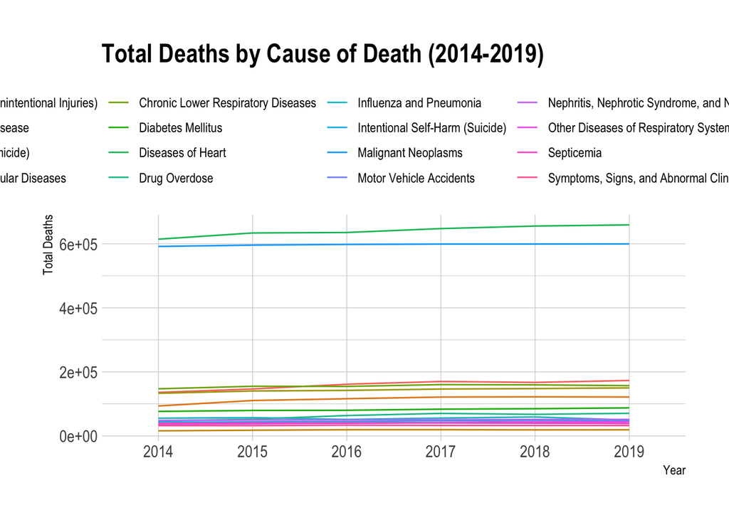

```r
ggplot(data = deaths_grouped, aes(x = year, y = total, group = Cause_of_Death, color = Cause_of_Death)) +
  geom_line() +
  ggtitle("Total Deaths by Cause of Death (2014-2019)") +
  xlab("Year") +
  ylab("Total Deaths") +
  theme_ipsum() + # Arial Narrow
  scale_fill_ipsum() +
  theme(legend.position = "top")
```